# forcats::fct_lump - Tidyverse - Data 607

Justin Hsi

2020-04-08

# Forcats - a package with useful functions when working with categorical data

## When working with a categorical variable that potentially has an enormous amount of levels, you can use forcats::fct_lump() to quickly group less common levels and focus on what levels you think are important

Let’s load the rarepepe dataset [(article here).](https://fivethirtyeight.com/features/pepe-the-frog-symbolism-cryptoart-blockchain/)

```r
order_all = read_csv('https://raw.githubusercontent.com/fivethirtyeight/data/master/rare-pepes/ordermatches_all.csv')
```

Let’s say you wanted to examine a categorical variable with too many levels. The rarepepe dataset has the names of rarepepe artworks which create many levels. If you tried to do a plot of them vs their summed historical forward asset sales, you might get something unusable like this:

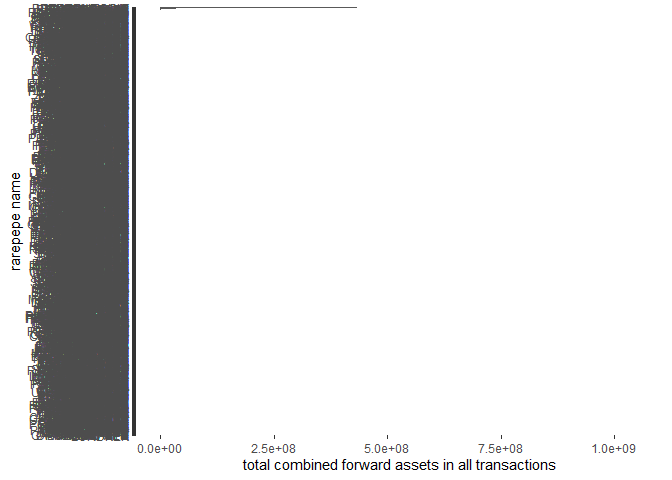

```r
f = factor(x = order_all$ForwardAsset)
order_all %>%
  group_by(ForwardAsset) %>%
  summarise(summed_for_quant = sum(ForwardQuantity)) %>%
  ggplot(aes(x = fct_reorder(ForwardAsset, summed_for_quant), y = summed_for_quant)) +
  geom_col() + coord_flip() + labs(x='rarepepe name', y='total combined forward assets in all transactions')
```

Part of what makes this visualization not helpful is the overwhelming number of levels. We can reduce this with *fct_lump*, as it will group the factors that do not occur frequently enough into a single level called “Other”. Here we choose the 15 most frequently occuring levels/artworks :

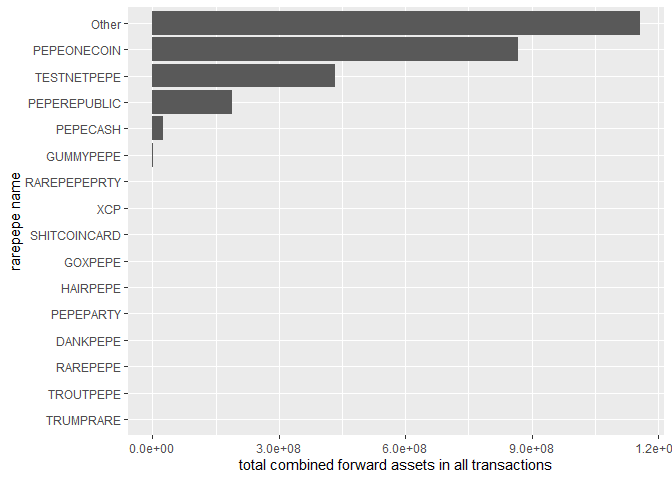

```r
f = factor(x = order_all$ForwardAsset)
order_all$ForwardAsset = fct_lump(f, 15)
order_all %>%
  group_by(ForwardAsset) %>%
  summarise(summed_for_quant = sum(ForwardQuantity)) %>%
  ggplot(aes(x = fct_reorder(ForwardAsset, summed_for_quant), y = summed_for_quant)) +
  geom_col() + coord_flip() + labs(x='rarepepe name', y='total combined forward assets in all transactions')
```